# HW4 : 석사 2학기 이동규

### **Library**

```r
library(tidyverse)
library(tidytext)
library(forcats)
library(lubridate)
library(aRxiv)
library(reshape2) #dcast function
library(wordcloud)
```

## 1.Recover the figure on p.15 of Lectrue Slide 10.

```r
data("data_corpus_inaugural", package = "quanteda")
inaug_dfm <- quanteda::dfm(data_corpus_inaugural,
                           verbose = FALSE)
inaug_td <- tidy(inaug_dfm)
inaug_tf_idf <- inaug_td %>%
  bind_tf_idf(term, document, count)
```

tf_idf를 생성한다.

```r
data <- inaug_tf_idf %>%
  filter(document %in% c('1861-Lincoln','1933-Roosevelt','1961-Kennedy',
                         '2009-Obama')) %>%
  group_by(document) %>%
  arrange(desc(document),desc(tf_idf)) %>%
  top_n(10,tf_idf) %>%
  ungroup() %>%
  mutate(term = reorder_within(term, tf_idf,document))
data
```

```
## # A tibble: 43 x 6
##    document   term                    count       tf   idf  tf_idf
##    <chr>      <fct>                   <dbl>    <dbl> <dbl>   <dbl>
##  1 2009-Obama icy___2009-Obama            2 0.000738 4.06  0.00300
##  2 2009-Obama -___2009-Obama             44 0.0162   0.169 0.00274
##  3 2009-Obama jobs___2009-Obama           3 0.00111  2.45  0.00271
##  4 2009-Obama waters___2009-Obama         2 0.000738 3.37  0.00248
##  5 2009-Obama winter___2009-Obama         2 0.000738 3.37  0.00248
##  6 2009-Obama storms___2009-Obama         2 0.000738 3.37  0.00248
##  7 2009-Obama generation___2009-Obama     5 0.00184  1.23  0.00226
##  8 2009-Obama father___2009-Obama         3 0.00111  1.98  0.00219
##  9 2009-Obama journey___2009-Obama        3 0.00111  1.98  0.00219
## 10 2009-Obama traveled___2009-Obama       2 0.000738 2.96  0.00219
## # ... with 33 more rows
```

필요한 데이터만 추출하고, 정렬을시킨다. 이때, reorder_within을 사용하여 정렬이 plot별로 이루어지게끔 한다.

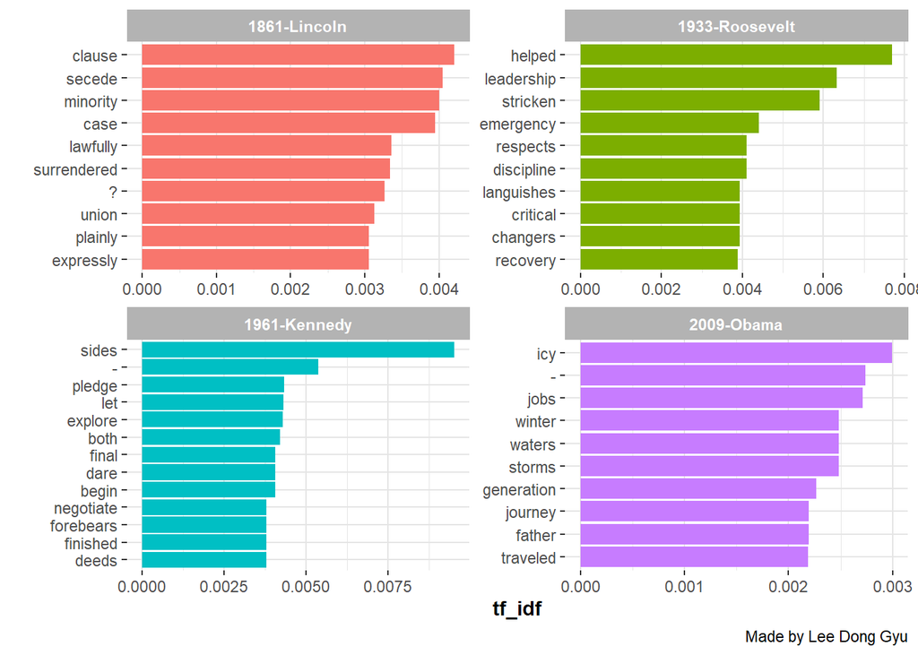

```r
data %>%
  ggplot(aes(term , tf_idf , fill=document)) +
  facet_wrap( ~ document, scales = 'free') +
  geom_bar(stat='identity',show.legend = FALSE) +
  scale_x_reordered() +

  labs(x="") +
  labs(caption = "Made by Lee Dong Gyu" ) +

  theme(
    strip.text.x = element_text(color = "white",face = "bold"),
    strip.text.y = element_text(color = "white",face = "bold"),
    strip.background = element_rect(color="gray70",fill="gray70",
                                    size=1.5, linetype="solid") ,
    axis.title.x = element_text(face='bold'),
    panel.background = element_blank() ,
    panel.grid.major.x = element_line(color='gray90') ,
    panel.grid.minor.x = element_line(color='gray90') ,
    panel.grid.major.y = element_line(color='gray90') ,
    panel.grid.minor.y = element_line(color='gray90') ) +
  coord_flip()
```

그림 완성.

## 2. Analyze the NN papers downloaded from aRxiv

```r
# NNPaper <- arxiv_search(query = '"Neural Network"', limit = 1000)
# NNPaper <- as_tibble(SVMPaper)
#
# NNPaper <- NNPaper %>%
#   mutate(submitted = ymd_hms(submitted), updated = ymd_hms(updated))
# write.csv(NNPaper,file='hello.csv') # write csv.
# glimpse(NNPaper)


tt <- read.csv('C:\\Users\\82104\\Desktop\\dat.csv') # data import
NNPaper<- tt[,-1]
NNPaper <- as_tibble(NNPaper)
NNPaper <- NNPaper %>%
  mutate(submitted = ymd_hms(submitted), updated = ymd_hms(updated))

NNPaper
```

```
## # A tibble: 1,000 x 15
##    id    submitted           updated             title abstract authors
##    <fct> <dttm>              <dttm>              <fct> <fct>    <fct>
##  1 hep-~ 1992-09-04 19:55:10 1992-09-04 19:55:10 "A C~ "  The ~ David ~
##  2 cond~ 1993-04-16 07:43:08 1993-04-16 07:43:08 "Tra~ "  We s~ A. Cri~
##  3 comp~ 1993-05-13 22:26:11 1993-05-13 22:26:11 "Ide~ "  Time~ Robert~
##  4 comp~ 1993-05-27 00:48:00 1993-05-27 00:48:00 "Glo~ "  We u~ I. G. ~
##  5 adap~ 1993-06-02 20:55:57 1993-06-02 20:55:57 "Bia~ "  Neur~ Russel~
##  6 cond~ 1993-06-15 01:54:55 1993-06-15 01:54:55 Opti~ "  Gard~ G. M. ~
##  7 cond~ 1993-06-17 15:15:00 1993-06-17 15:15:00 Neur~ "  We p~ J. J. ~
##  8 cond~ 1993-08-04 16:40:00 1993-08-04 16:40:00 Stoc~ "  Neur~ Caren ~
##  9 cond~ 1993-08-12 06:45:14 1999-03-27 06:20:13 Supe~ "  We p~ M. V. ~
## 10 cond~ 1993-10-23 10:27:21 1993-10-23 10:27:21 "Mea~ "  We m~ V. G. ~
## # ... with 990 more rows, and 9 more variables: affiliations <fct>,
## #   link_abstract <fct>, link_pdf <fct>, link_doi <fct>, comment <fct>,
## #   journal_ref <fct>, doi <fct>, primary_category <fct>, categories <fct>
```

위의 주석대로 데이터를 부른다. 그리고 이렇게 부른 데이터를 따로 저장하여 관리하였다. SVM이 아닌, Neural Network에 관한 논문을 찾아보았다.

```r
NNPaper$abstract <- as.character(NNPaper$abstract)
data1 <- NNPaper %>%
  select(abstract) %>%
  unnest_tokens(word,abstract)
```

2-1에서 사용할 데이터를 목적에 맞게 추출하고 정비하였다.

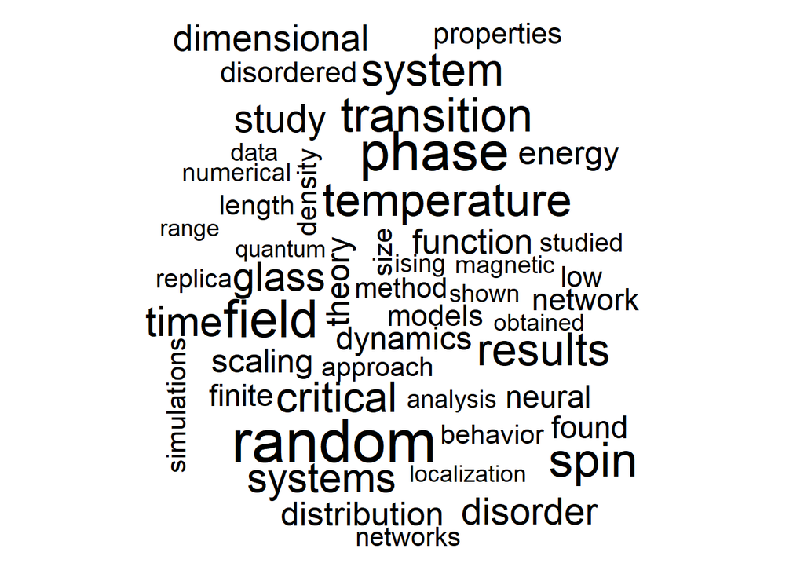

```r
data1 %>%
  anti_join(stop_words) %>%
  filter(!str_detect(word,'[\\d]')) %>%  #eliminating digit
  count(word) %>%
  with(wordcloud(word,n,max.words=50), random.order=FALSE)
```

wordcloud를 확인한다.

#### 2-2.Which year is generating these papers most freqently?

```r
data2 <- NNPaper %>%
  select(submitted,authors,title) %>%
  extract(submitted,"year","(\\d+)",convert=TRUE) %>%
  group_by(year) %>%
  summarize(n=n()) %>%
  mutate(year=factor(year))
```

2-2에서 사용할 데이터를 목적에 맞게 추출하고 정비하였다.

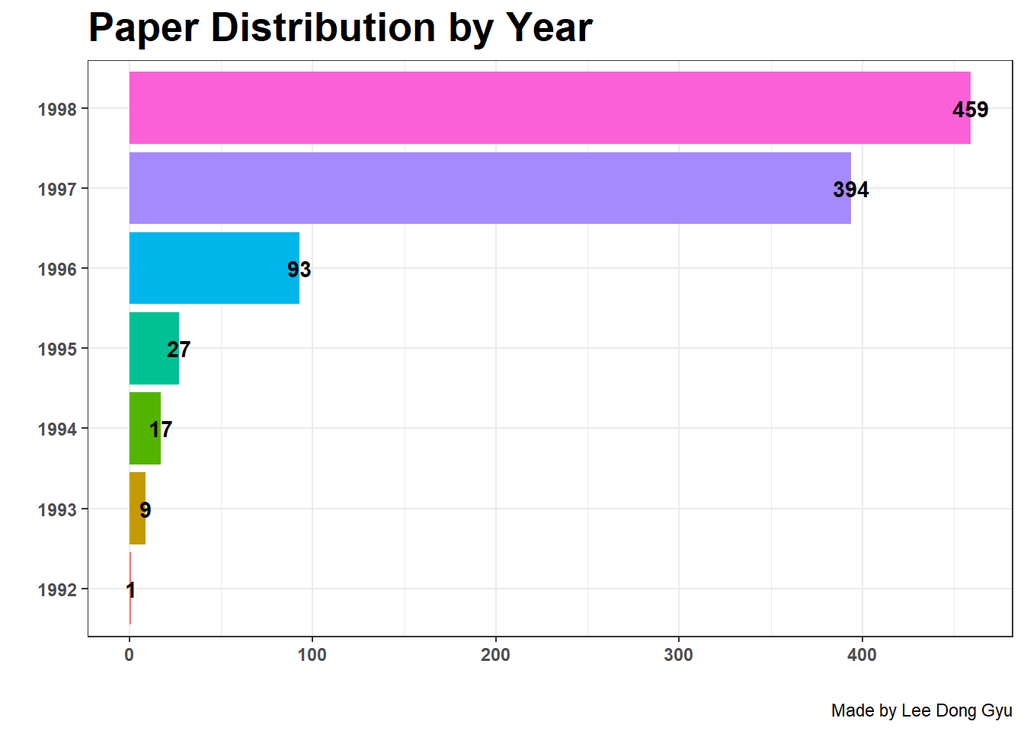

```r
data2 %>%
  ggplot(aes(year , n , fill=year)) +
  geom_bar(stat='identity',show.legend = FALSE) +

  labs(x="",y="") +
  geom_text(aes(label=n), position = position_dodge(width=0.7),fontface = "bold") +

  ggtitle("Paper Distribution by Year") +
  labs(caption = "Made by Lee Dong Gyu" ) +

  theme_bw()+
  theme(
    plot.title = element_text(face='bold',size=20),
    strip.text.x = element_text(color = "white",face = "bold"),
    strip.text.y = element_text(color = "white",face = "bold"),
    strip.background = element_rect(color="gray70",fill="gray70",
                                    size=1.5, linetype="solid") ,
    axis.title.x = element_text(face='bold'),
    axis.text.y=element_text(face='bold'),
    axis.text.x=element_text(face='bold')) +
  coord_flip()
```

연도별 논문수의 분포를 확인한다.

#### 2-3.What fields are generating these papers most frequently? (Check primary_category)

```r
data3 <- NNPaper %>%
  select(primary_category) %>%
  group_by(primary_category) %>%
  summarize(n=n()) %>%
  mutate(primary_category=reorder(primary_category,n))
```

2-3에서 사용할 데이터를 목적에 맞게 추출하고 정비하였다.

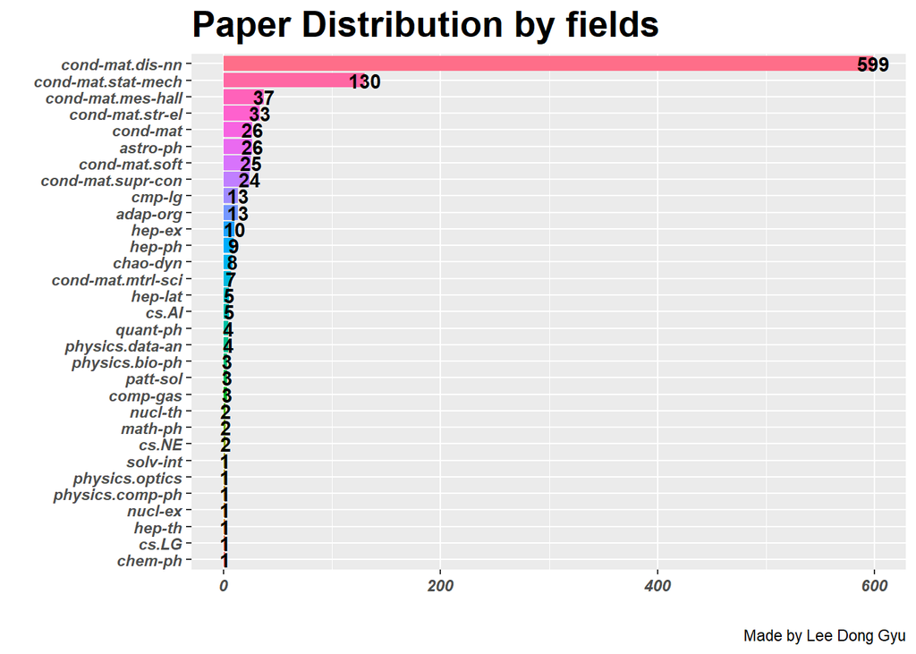

```r
data3 %>%
  ggplot(aes(primary_category , n , fill=primary_category)) +
  geom_bar(stat='identity',show.legend = FALSE) +

  labs(x="",y="") +
  geom_text(aes(label=n), position = position_dodge(width=0.7),fontface = "bold") +

  ggtitle("Paper Distribution by fields") +
  labs(caption = "Made by Lee Dong Gyu" ) +

  theme(
    plot.title = element_text(face='bold',size=20),
    strip.text.x = element_text(color = "white",face = "bold"),
    strip.text.y = element_text(color = "white",face = "bold"),
    strip.background = element_rect(color="gray70",fill="gray70",
                                    size=1.5, linetype="solid") ,
    axis.title.x = element_text(face='bold'),
    axis.text.y=element_text(face='bold.italic'),
    axis.text.x=element_text(face='bold.italic')) +
  coord_flip()
```

영역별 논문수를 확인한다.

#### 2-4.Caculate tf-idf matrix. Here, the document is “article”.

```r
data4 <- NNPaper %>%
  select(title,abstract) %>%
  mutate(abstract=as.character(abstract)) %>%
  unnest_tokens(word,abstract) %>%
  count(title,word,sort=TRUE) %>%
  bind_tf_idf(word,title,n)
```

2-4에서 사용할 데이터를 목적에 맞게 추출하고 정비하였다.

```r
tf_idf_matrix <- data4 %>%
  select(title, word, tf_idf) %>%
  dcast(word ~ title) %>%
  as_tibble()
tf_idf_matrix[,1:5]
```

```
## # A tibble: 7,200 x 5
##    word  `(4+N)-Dimensio~ `1-loop contrib~ `2d frustrated ~
##    <chr>            <dbl>            <dbl>            <dbl>
##  1 _2                  NA               NA               NA
##  2 _3                  NA               NA               NA
##  3 _6                  NA               NA               NA
##  4 _c                  NA               NA               NA
##  5 _m                  NA               NA               NA
##  6 _t                  NA               NA               NA
##  7 0                   NA               NA               NA
##  8 0,0.~               NA               NA               NA
##  9 0,1                 NA               NA               NA
## 10 0.000               NA               NA               NA
## # ... with 7,190 more rows, and 1 more variable: `2D Lattice of coupled
## #   Sinai billiards: metal or insulator at g<<1` <dbl>
```

```r
dim(tf_idf_matrix)
```

```
## [1] 7200 1000
```

#### 2-5.Conduct cluster analysis for the articles based on the tf_idf matrix.

```r
#kmeans

tf_idf_matrix[is.na(tf_idf_matrix)] <- 0
row_name <- tf_idf_matrix[,1] # terms
data5 <- as.matrix(tf_idf_matrix[,2:1000])
col_name <- colnames(data5) # document names
data5 <- t(data5)
```

2-5에서 사용할 데이터를 목적에 맞게 추출하고 정비하였다. 그리고 kmeans방법을 통해 논문을 그룹지을 것이며 k=3, k=4일 경우에 대해 시행해보았다.

```r
# divided into 3 groups
kmeans2_5_group3 <- kmeans(data5,3)
cluster <- as_tibble(kmeans2_5_group3$cluster) %>%
  mutate(document=col_name)
cluster_1 <- length(cluster$value[cluster$value == 1])
cluster_2 <- length(cluster$value[cluster$value == 2])
cluster_3 <- length(cluster$value[cluster$value == 3])
c(cluster1=cluster_1 , cluster2=cluster_2,cluster3=cluster_3)
```

```
## cluster1 cluster2 cluster3
##        3      183      813
```

논문들을 3그룹으로 나눠보았고, 이때 각 그룹의 개수를 출력해보았다.

```r
# divided into 4 groups
kmeans2_5_group4 <- kmeans(data5,4)
cluster <- as_tibble(kmeans2_5_group4$cluster) %>%
  mutate(document=col_name)

cluster_1 <- length(cluster$value[cluster$value == 1])
cluster_2 <- length(cluster$value[cluster$value == 2])
cluster_3 <- length(cluster$value[cluster$value == 3])
cluster_4 <- length(cluster$value[cluster$value == 4])
c(cluster1=cluster_1 , cluster2=cluster_2,cluster3=cluster_3,cluster4=cluster_4)
```

```
## cluster1 cluster2 cluster3 cluster4
##      630        3      193      173
```

이번에는 4그룹으로 나눠보았고, 이때 각 그룹의 개수를 출력해보았다.